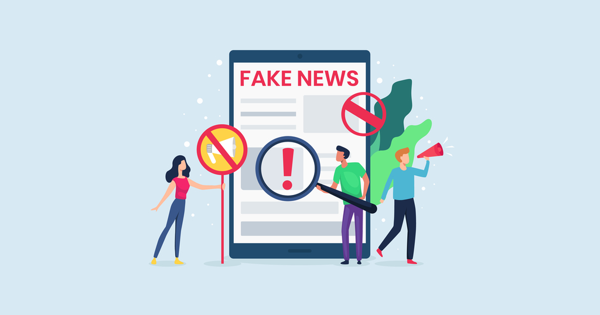

# Introduction

Fake news is a broad term and in this project and specifically in this notebook, we will dive into fake and real covid-19 tweets. We will see what data we have, how it was collected then we will have a basic understanding of the data. Next, we will explore the data by asking questions and coming up with hypotheses about the data. In addition to that, we shall analze a sample of data to see what potentional problems in the data. Last, we will display our findings in a short way to conclude the notebook.

## Problem understanding

News can be in many different forms. For example, Newspapers, Magazines, TV and radio, Internet, News agencies and Alternative media. Now, there are some businesses that try to promote their products or to advertise a product and some publish fake, attractive or charming news as 'clickbait' and we tend to be curious when it comes to unusual things and so we read / check the content. For instance, in 1835 newspaper company claimed that they have found out creates live in moon (humans with wings) [here is link for full article](https://www.newyorker.com/books/page-turner/moon-shot-race-a-hoax-and-the-birth-of-fake-news). That as a consequence allowed the company to be more popular which allowed them to promote and advertise more. Now this is one of the reasons why would certain group of people / a person publish fake news or misleading information. However, the influnce on the reader is usually harmful. For example, it could be that fake news regards healthy food suggest or recommend some types of food for people who suffer from kind of illness and if reader followed the suggestions that could be in fact harmful for them since news were fake in the first place. There are more scenarios obviously but this is where the problem lies. Fake news in general are published for the sake of obtaining profit most of the time and readers might believe misleading information which could influence their decisions.

In this research though, the focus will be on the news of covid-19 topic (tweets) and various topics of fake, legit articles published on the internet.

## Research question

- Based on the classified covid-19 tweets as fake and real with the tweet text being available 'How is it possible to predict whether a new tweet tend to be fake or real?'

With this question in mind, the part of predicting the reliability of covid-19 tweet should be clear (half of the project) and the other half (fake and legit internet articles) will be in another notebook.

## Expectations of this notebook

After reading this notebook you should have:

- Understood the dataset at hand regarding covid 19 tweets.
- Understood how the data was collected.
- Basic understanding of the data.
- Understood different questions used to explore the data.
- Conclusions whether some hypotheses were correct or incorrect.

# Table of content

## Table of content:

- Introduction
- Data requirement
- Data collection
- Loading libraries and the dataset
- Basic understanding of data
- Exploratory data analysis
- Conclusions

# Data requirement

In this section I will describe the obtained data, its format, the number of columns and rows in addition to a description of each column.

## Description of obtained data

The dataset is about some tweets which was taken from Twitter (social media platform) and classified by the dataset owner(s) as fake and real tweets in 2021.

## Format of the data

The acquired dataset of covid-19 tweets is in CSV-format which can be easily stored locally on the machine.

## General information about the dataset

The acquired dataset of covid-19 tweets consists of 6420 rows and 3 columns.

The columns being as the following:

- **id**, which represents a unique number for each tweet in the dataset.
- **tweet**, which represents the text or body of what has been tweeted or sent via the Twitter platform.
- **label**, which represents whether a tweet was considered to be fake or legit according to the dataset owner(s).

# Data collection

In this section I will describe where, how the data was acquired and pontential problems could arise while attempting to acquire them in addition to some remarks.

## Where the data can be obtained?

The data can be obtained through this [link](https://github.com/diptamath/covid_fake_news/tree/main/data), which is a github repository where the dataset owner has uploaded as an open-source data in addition to their own version of classifying fake and real covid-19 tweets.

The dataset file name: Constraint_Train.csv

## How the data can be obtained?

In the previous sub-section I provided a link to where the data can be obtained. However, after clicking the link you will need to either download the entire repository as ZIP file or use git to get the repository in your local machine. Please follow one of the two possible twos:

1. recommend way (ZIP file)

[figure not shown]

[figure not shown]

[figure not shown]

1. Cloning the repository:
- This way you will be able to clone a copy of the entire repository via git command line. (first you will have to dowbload [git](https://git-scm.com/downloads)).
- Open a folder you desire to have the cloned repository in.
- Copy the repository link.
- Open the git commander and type 'git clone (repository link)' and hit enter.

Please consider the following pictures for clarification:

[figure not shown]

[figure not shown]

[figure not shown]

## Potential problems can be encountered?

The second approach of obtaining the repository can be a bit difficult to people who never worked with git before, therefore they can receive errors in command line due to some type errors or incorrect git setup. A common issue is that they would need to setup their global name and email before they can clone. So I would suggest searching about git and how to set it up correctly in your local machine. It is a powerful version control system but can be tricky for beginners.

## Remarks

The data contains the label column which was assigned by the dataset owner(s) as fake or reliable. As a result, the data is considered to be subjective and could be biased. However, my research requires a labeled dataset as it will be the target variable in the project with that being said I shall attempt my best to reduce bias in this research as much as possible. In addition the column 'id' is not really useful for the project because it is only a unique identifier, therefore in the preparation notebook I shall be dropping it.

# Loading libraries and the dataset

```python
import matplotlib.pyplot as plt
import seaborn as sns
import numpy as np
import pandas as pd
import re
import nltk
from nltk.corpus import stopwords
from nltk.stem.porter import PorterStemmer
from nltk.stem import WordNetLemmatizer
import spacy

nlp = spacy.load('en_core_web_sm')

from langdetect import detect, DetectorFactory
DetectorFactory.seed = 0


from wordcloud import WordCloud
from textwrap import wrap

from sklearn.feature_extraction.text import CountVectorizer
```

```python
df = pd.read_csv('covid19_tweets.csv')
```

## Explanation of the imported libraries

**Matplotlib**, Matplotlib is a comprehensive library for creating static, animated, and interactive visualizations in Python. Matplotlib makes easy things easy and hard things possible.

**Seaborn** Seaborn is a Python data visualization library based on matplotlib. It provides a high-level interface for drawing attractive and informative statistical graphics.

**Numpy** It is a Python library that provides a multidimensional array object, various derived objects (such as masked arrays and matrices), and an assortment of routines for fast operations on arrays, including mathematical, logical, shape manipulation, sorting, selecting, I/O, discrete Fourier transforms, basic linear algebra, basic statistical operations, random simulation and much more.

**Pandas** pandas is a fast, powerful, flexible and easy to use open source data analysis and manipulation tool, built on top of the Python programming language.

**re** A regular expression (or RE) specifies a set of strings that matches it; the functions in this module let you check if a particular string matches a given regular expression

**nltk** NLTK is a leading platform for building Python programs to work with human language data. It provides easy-to-use interfaces to over 50 corpora and lexical resources such as WordNet, along with a suite of text processing libraries for classification, tokenization, stemming, tagging, parsing, and semantic reasoning, wrappers for industrial-strength NLP libraries, and an active discussion forum.

**spacy** spaCy is a free open-source library for Natural Language Processing in Python. It features NER, POS tagging, dependency parsing, word vectors and more.

**langdetect** A python library that allows you to identify the language in a given string.

**wordcloud** Word Cloud is a data visualization technique used for representing text data in which the size of each word indicates its frequency or importance.

**CountVectorizer** CountVectorizer is a great tool provided by the scikit-learn library in Python. It is used to transform a given text into a vector on the basis of the frequency (count) of each word that occurs in the entire text.

# Basic understanding of data

In this section of this notebook, I shall check basic information about the dataset such as its shape, first a few data rows, column names, general information about the dataset and a description of the data. Then, I will conclude the findings at the end of the section.

```python
df.shape
```

```
(6420, 3)
```

```python
df.head()
```

|  | id | tweet | label |
| --- | --- | --- | --- |
| 0 | 1 | The CDC currently reports 99031 deaths. In gen... | real |
| 1 | 2 | States reported 1121 deaths a small rise from ... | real |
| 2 | 3 | Politically Correct Woman (Almost) Uses Pandem... | fake |
| 3 | 4 | #IndiaFightsCorona: We have 1524 #COVID testin... | real |
| 4 | 5 | Populous states can generate large case counts... | real |

```python
df.columns
```

```
Index(['id', 'tweet', 'label'], dtype='object')
```

```python
df.info()
```

```
<class 'pandas.core.frame.DataFrame'>
RangeIndex: 6420 entries, 0 to 6419
Data columns (total 3 columns):
 #   Column  Non-Null Count  Dtype
---  ------  --------------  -----
 0   id      6420 non-null   int64
 1   tweet   6420 non-null   object
 2   label   6420 non-null   object
dtypes: int64(1), object(2)
memory usage: 150.6+ KB
```

The following code only have 'tweet' and 'label' as these are non-numerical columns, as if I included 'id' for instance the description function will behave differently and only display numerical value which in this case the id only and that would not be useful.

```python
df[['tweet','label']].describe()
```

|  | tweet | label |
| --- | --- | --- |
| count | 6420 | 6420 |
| unique | 6420 | 2 |
| top | Medical director at PHE Dr Yvonne Doyle says h... | real |
| freq | 1 | 3360 |

```python
df.label.value_counts()
```

```
real    3360
fake    3060
Name: label, dtype: int64
```

## Findings

The data set has 6420 rows, each represents a tweet. There are no duplicate tweets and there is only 2 unique labels. The fake tweets is almost less a bit than half of the dataset and the real tweets is about 52% of the dataset which indicate balance in the target variable.

# Exploratory data analysis

## Questions used to explore the data

The following are arising questions which I use to help me explore the dataset:

- What is the relationship between the reliability(fake/legit) and the length (characters) of the tweet?
- What is the relationship between the reliability(fake/legit) and the length (words) of the tweet?
- What is the relationship between the reliability(fake/legit) and the length (sentences) of the tweet?
- Are all the tweets in the dataset in English language?
- What are top common words that appear in fake tweets and real tweets?
- What kind of problems can be found in the tweet text ? (which can be fixed in the data preparation pre-processing part)

## hypotheses

The following are my hypotheses regarding the questions mentioned the in the previous sub-section:

- I think that if the tweet has less length, it tends to be real because that means that the tweet more less like a summary which tend to true.
- I think 'claim' is one of the top words mentioned in the fake tweets, whereas 'reported' in the top words mentioned in the real tweers as 'claim' usually indicate what is about to mentioned is not 100% correct and 'reported' often used to display finding after some kind of research.

## Label disturbtion

In this part of exploratory data analysis I will visualize the count of real anad fake tweets of the target variable (label) to double check if the dataset is balanced or not.

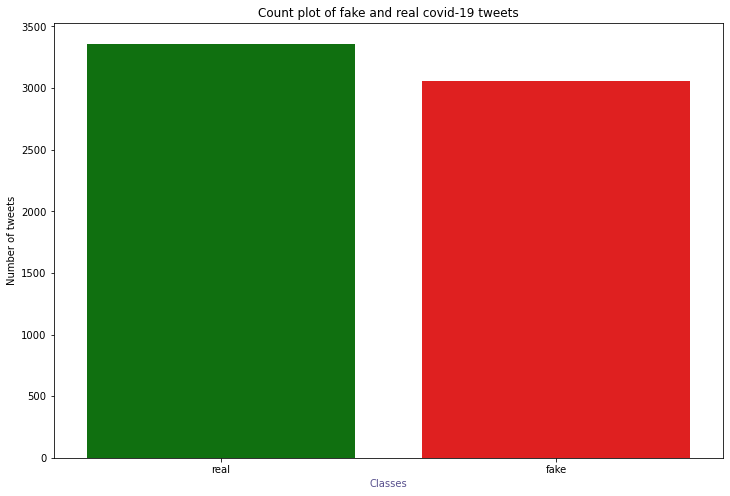

```python
#Palette
cols= ["green", "red"]

plt.figure(figsize=(12,8))
fg = sns.countplot(x= df["label"], palette= cols)
fg.set_title("Count plot of fake and real covid-19 tweets")
fg.set_xlabel("Classes", color="#58508d")
fg.set_ylabel("Number of tweets")
```

### Findings

The target variable contains almost the same amount of fake and real covid19 tweets which means that indeed the dataset is balanced.

## Exploring the length of tweets

In this part of exploratory data analysis I shall visualize the length of chatacters, words and sentences with the reliability label and conclude whether my hyothesis regarding that was correct or not.

### Feature engineering (creating length per character, word and sentence)

In this sub-section of exploratory data analysis I shall use feature engineering to create 3 columns which represent the number of characters, words and sentences in a tweet. Then, I will be demonstrating the statistics of those columns in addition to attempting to find out relationship between them and the reliability column (label). Last, I will conclude the sub-section by checking whether or not the hypothesis was correct.

```python
df["No_of_Characters"] = df["tweet"].apply(len)

df["No_of_Words"]=df.apply(lambda row: nltk.word_tokenize(row["tweet"]), axis=1).apply(len)

df["No_of_sentence"]=df.apply(lambda row: nltk.sent_tokenize(row["tweet"]), axis=1).apply(len)

df.describe().T
```

|  | count | mean | std | min | 25% | 50% | 75% | max |
| --- | --- | --- | --- | --- | --- | --- | --- | --- |
| id | 6420.0 | 3210.500000 | 1853.438696 | 1.0 | 1605.75 | 3210.5 | 4815.25 | 6420.0 |
| No_of_Characters | 6420.0 | 181.614019 | 150.552554 | 18.0 | 111.00 | 169.0 | 255.25 | 8846.0 |
| No_of_Words | 6420.0 | 32.711682 | 27.530570 | 3.0 | 19.00 | 30.0 | 45.00 | 1594.0 |
| No_of_sentence | 6420.0 | 2.028037 | 1.648358 | 1.0 | 1.00 | 2.0 | 3.00 | 81.0 |

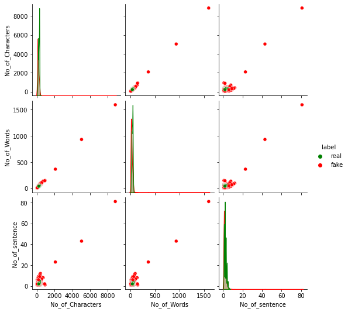

```python
df_subset = df[['No_of_Characters','No_of_Words','No_of_sentence','label']]
plt.figure(figsize=(12,8))
fg = sns.pairplot(data=df_subset, hue="label",palette=cols)
plt.show(fg)
```

It is not exactly clear what the relation is due to having outliers in each of character, word and sentence lengths. I will try to zoom in to see whether the picture gets clearer without the outliers.

**Note**: From above data visualization, it is clear to me that range of less than 500 characters, less than 200 characters and less than 5 sentences would result in more informative graph.

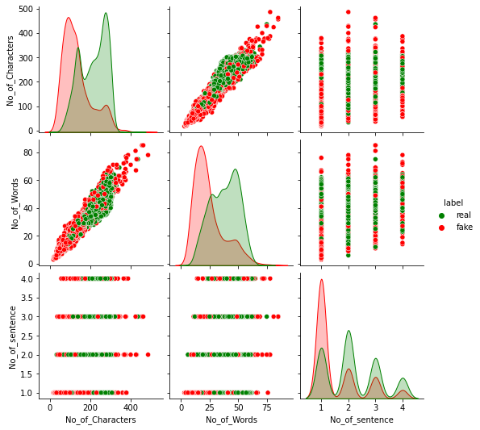

```python
df_subset = df[(df['No_of_Characters']< 500) & (df['No_of_Words']< 200) & (df['No_of_sentence']< 5)][['No_of_Characters','No_of_Words','No_of_sentence','label']]
plt.figure(figsize=(12,8))
fg = sns.pairplot(data=df_subset, hue="label",palette=cols)
plt.show(fg)
```

### Findings

**hypothesis**: I think that if the tweet has less length, it tends to be real because that means that the tweet more less like a summary which tend to true.

Therefore, the hypothesis was wrong the data shows that the less length the tweet is the higher chance of it being fake tweet.

## Language detection of the data

In this section, I shall check whether the raw text all in english laanguage or not using different techniques such as regular expression and specific python libraries.

### Appendix of the functionality used

```python
detect('今一はお前さん')
```

```
'ja'
```

#### Findings

Detect functionality allows you to detect which language the inputted string is.

### Looping through the tweets for language detection

```python
for index,value in enumerate(df['tweet']):
    if bool(re.match('^(?=.*[a-zA-Z])', str(value))) == False :
        print(index,value)
```

```
4456 #कल_9सितम्बर_याद_है_ना

Raise your voice against:

🔹️GDP crash

🔹️Massive unemployment

🔹️Rising coronavirus cases

🔹️Sale of profit-making PSU's

🔹️Increasing farmer suicide

🔹️Rise in crimes against women https://t.co/EkL8b7hXzh
```

```python
def language_detector(text):
    return  detect(text)
```

```python
df['language']=df['tweet'].apply(language_detector)
```

```python
df['language'].value_counts()
```

```
en    6375
de       8
es       8
fr       6
ca       5
ro       4
it       3
tl       3
pt       2
id       2
nl       1
sv       1
no       1
af       1
Name: language, dtype: int64
```

### Findings

The majority of tweets were written in english. After using different techniques of detecting languages used by using regular expression and specific language detection library I was able to derive the conclusion that the data does contain tweets which are not in english language.

## top words that appear in fake tweets and real tweets

In this section I shall attempt to get the most important words mentioned in tweets that indicate fake tweets and real tweets and see if my hypothesis was correct or not and derive conclusions.

### Group the tweets according to their reliability

Here I will group the entire corpus of all fake tweets into 1 large corpus and all real news into 1 large corpus so that in next chapters I can perform what is known as Document Term Matrix, which indicates on the columns each possible word that was mentioned in one of the tweets and its amount of occurences in row correspondingly. That will allow me to generate a cloud visualization to see important words mentioned in both fake tweets and real tweets.

```python
# group all fake tweets together and real tweets together
df_group=df[['tweet','label']].groupby(by='label').agg(lambda x:' '.join(x))
df_group.head()
```

| label | tweet |
| --- | --- |
| fake | Politically Correct Woman (Almost) Uses Pandem... |
| real | The CDC currently reports 99031 deaths. In gen... |

### Visualize the corpse

In this sub-section I will use the grouped tweets text for each label (each corpus) and transform it into a matrix where each word indicate how important it is to the corpus and finally use WordCloud as data visualization to see important words for each label.

The following function takes in the data and title to spit out word cloud data visualization

```python
# Function for generating word clouds
def generate_wordcloud(data,title):
  wc = WordCloud(width=400, height=330, max_words=150,colormap="Dark2").generate_from_frequencies(data)
  plt.figure(figsize=(10,8))
  plt.imshow(wc, interpolation='bilinear')
  plt.axis("off")
  plt.title('\n'.join(wrap(title,60)),fontsize=13)
  plt.show()
```

I will create now a matrix where each row represent a word that was present in the corpus of each fake and real with the corresponding reliability. Also stop words such as 'The, I, you' are words that occur too often but does not actually influence what we are trying to do therefore I will remove them in the CountVectorizer parameter.

```python
cv=CountVectorizer(analyzer='word',stop_words ='english')
data=cv.fit_transform(df_group['tweet'])
df_dtm = pd.DataFrame(data.toarray(), columns=cv.get_feature_names())
df_dtm.index=df_group.index
df_dtm=df_dtm.transpose()
df_dtm.sample(3)
```

| label | fake | real |
| --- | --- | --- |
| dr_sourabhkp | 1 | 0 |
| favourite | 1 | 0 |
| concerts | 0 | 1 |

Now we will plot the words.

[figure not shown]

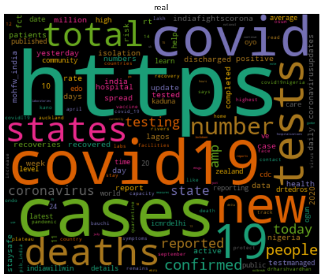

```python
for index,tweet in enumerate(df_dtm.columns):
  generate_wordcloud(df_dtm[tweet].sort_values(ascending=False),tweet)
```

### Findings

- We can notice that words such as lockdown, vaccine, claim and cure appear often in fake covid-19 tweets.
- We can notice that the word https appear in both fake and real news which indicate that we probably have many hyper links in both fake and real tweets.
- We can notice that words such as reported, confirmed, update and deaths appear often in real covid-19 tweets.
- We can notice that there are some words that appear in both fake and real covid-19 tweets. For example, while new, cases and states are emphasized that the tweet more likely to be real tweet, it is also possible that it could be fake since those words also in fake tweets but not emphasized as much.

Hypothesis was: I think 'claim' is one of the top words mentioned in the fake tweets, whereas 'reported' in the top words mentioned in the real tweers as 'claim' usually indicate what is about to mentioned is not 100% correct and 'reported' often used to display finding after some kind of research.

- Therefore the hypothesis was correct claim did appear on the important words of fake tweets corpus and reported did appear on the important words of real tweets corpus.

## Finding out tweet text issues

In this section, I will be taking a sample of the tweets and check what could be problematic in the text and what are possible fixes.

```python
for index,text in enumerate(df['tweet'][100:120]):
  print('Review %d:\n'%(index+1),text)
```

```
Review 1:
 Says Rudy Giuliani "bought $2M in shares of Novartis, a primary supplier of hydroxychloroquine" in early February.
Review 2:
 _A student from Pondicherry University in India has found a home remedy for COVID-19 that has been accepted by World Health Organization (WHO)._
Review 3:
 Footballer Ronaldo is turning his hotels into COVID-19 hospitals.
Review 4:
 #CoronaVirusUpdates India records Highest ever single day peak of 63631 #COVID19 recoveries. #IndiaFightsCorona as Total recoveries cross 22 lakh. Recoveries exceed the active cases by more than 15 lakh. https://t.co/XBY3Er8K0P https://t.co/VDQSv7xVUB
Review 5:
 Do you have a cough fever or runny nose? If these symptoms came on suddenly there’s a good chance you could have #flu. Watch to find out what you should do next to #fightflu. https://t.co/fp3aSjumw4
Review 6:
 President Trump Says Pandas Are Responsible For Covid-19 https://t.co/mgan5G2oY8 #donaldtrump #china #coronavirus #zoo #pandas
Review 7:
 As of today there are 23917 active #COVID19 cases in #Mumbai District #Maharastra: https://t.co/6CcqIYgbXL @MoHFW_INDIA @drharshvardhan @DrHVoffice @MantralayaRoom #COVID__19 #Covid_19 #COVIDー19 #CoronaUpdatesInIndia #Coronavirus #CoronaVirusUpdates #CoronavirusPandemic https://t.co/k6ICon5kZ6
Review 8:
 Public Health England's weekly #coronavirus report shows a rise of almost 23% in rhinovirus infections which include the common cold in the last week https://t.co/N6jzZYU7lJ
Review 9:
 This is an image of a suspected coronavirus vaccine causing COVID-19.
Review 10:
 Some people are more likely than others to become severely ill from #COVID19 which means that they may require hospitalization intensive care or a ventilator to help them breathe. Some severely ill people may die. Learn more. https://t.co/15lxFaQqX7 https://t.co/MAnreCAV8G
Review 11:
 Camila Pitanga Brazilian actress contracted COVID-19 but said she caught malaria so she could take chloroquine without admitting she was wrong.
Review 12:
 The new coronavirus "causes sudden death syndrome."
Review 13:
 #IndiaFightsCorona: 📍 Increasing gap between #COVID19 Recovered &amp; Active cases of India (May 04 2020 to September 11 2020)👇 #StaySafe #IndiaWillWin https://t.co/FFJ4DKyspR
Review 14:
 Coronavirus parties can have deadly consequences. https://t.co/WTriJWJu9T
Review 15:
 Cabinet Office Minister Michael Gove says 'there's going to be a shift of emphasis' on working from home in the new #COVID19 restrictions. #KayBurley Get the latest #coronavirus news: https://t.co/hk8hrup8AY https://t.co/q8Btm4YE1P
Review 16:
 @James_Gross Well they are now reporting quite effectively. It's just they refuse to put their numbers in a table or dashboard for reasons that are beyond me.
Review 17:
 Looking at the numbers this is not like yesterday where one state (California) drove a huge increase. This number seems much more solid driven by a number of states reporting large numbers of tests completed.
Review 18:
 India has lost over 50000 individuals to coronavirus till date. In view of the rising coronavirus cases Bihar government extends lockdown in the state till 6 September. At Nationalist Congress Party chief Sharad Pawar’s residence four people tested positive for #coronavirus. https://t.co/LqGJHHVr2g
Review 19:
 Bill Gates profits from vaccination and wants to reduce the world's population.
Review 20:
 #IndiaFightsCorona: @MoHFW_INDIA held a virtual meeting today with States &amp; UTs to ensure adequate Oxygen availability in all healthcare facilities &amp; unrestricted intra as well as inter State movement of oxygen. Read Details: https://t.co/cFx0MYEcFx #StaySafe #IndiaWillWin https://t.co/6jA2…
```

### Things to be noticed

- Text can be all lowered case.
- Text contain punctuations example, review 1 contain dot at the end.
- Some reviews contain hyperlinks. For example, review 20 mentioned this link https://t.co/cFx0MYEcFx .
- Some text contain short contractions. For example, review 16: Note: It's and the expanded version of it is 'It is'.
- Tweets contain hashtags. For example, review 7: this hash tag was mentioned @drharshvardhan and #CoronaUpdatesInIndia
- Some tweets contain emojis. For example, review 13: contains this emjoi 📍
- Some text contain digits. For example, review 18 mentioned that 50000 individuals

**Note**: Keep in mind that the model that is going to be created should give results according to keywords of the tweets, thus digits should not matter as covid-19 figures changes and there is no way for the model I am developing to distinguish the 'fake' or 'real' tweets based on the digits.

### Findings

After analyzing a sample of the data we have derived that the text contain some problems such as capalization, punctuations, hyperlinks involved, short contractions (example, It's), different hash tags that start with @ or #, various emojis in the text and the text contain digits which would not be useful for us in the prediction section.

Therefore the list of fixes for the text as follows:

1. Lowercase all the text
2. Expand Contractions
3. Remove hyperlinks
4. Remove hashtags
5. Remove punctuations
6. Remove emojis
7. Remove digits

After that we should have clean text, but in order to continue processing it we would need to remove stopwords as they appear often in text corpus while not indicating actual meaning and need to use lemmatization technique in order to bring the words from various tense forms into their base form (example. 'Went' --use lemma--> 'Go')

# Conclusions

To conclude this notebook, although fake news is a broad term our focus in this research was on covid-19 tweets and online articles (which will be covered in different notebook.), fake news in general are published for the sake of obtaining profit most of the time and readers might believe misleading information which could influence their decisions.

The data we worked on contains 3 columns id,tweet,label and around 6420 rows while id indicate a unique identifier, tweet indicate text that was sent and the label indicate the reliability of the tweet. The label column was created by the dataset owner which is subjective and could be biased but this research require a labeled data. The dataset can be easily stored in machine locally due to its size and its format. There are no duplicate tweets and there is only 2 unique labels. The fake tweets is almost less a bit than half of the dataset and the real tweets is about 52% of the dataset which indicate balance in the target variable.

The dataset contain text issues which can be fixed with the following methods:

1. Lowercase all the text
2. Expand Contractions
3. Remove hyperlinks
4. Remove hashtags
5. Remove punctuations
6. Remove emojis
7. Remove digits